# Analiza Interactiva a Evaluarilor

**Autor:** Georgiana Mutascu Explica faptul ca analizezi cum evolueaza increderea clientilor in timp si care categorii de produse sunt "vedetele" magazinului online.

```
Nota maxima primita de un produs: 9.75
Nota minima primita de un produs: 5.5
------------------------------
```

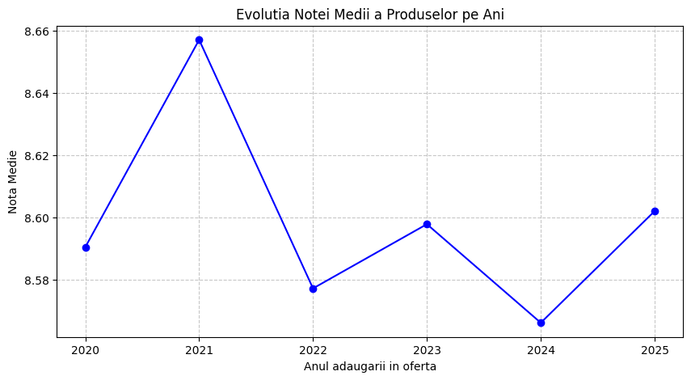

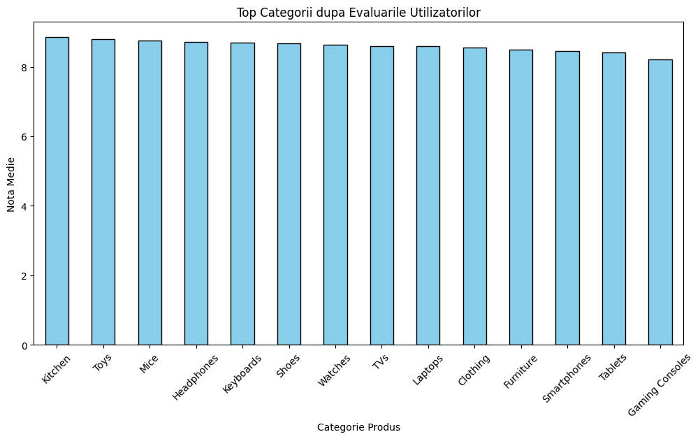

```python
import pandas as pd
import matplotlib.pyplot as plt

# 1. Incarcarea datelor
df = pd.read_csv('online_store_data.csv')

# 2. Pregatirea datei (Extragerea anului)
df['date_added'] = pd.to_datetime(df['date_added'])
df['year'] = df['date_added'].dt.year

# 3. Calcularea valorilor extreme (Task: Rezultat textual)
rating_max = df['rating'].max()
rating_min = df['rating'].min()

print(f"Nota maxima primita de un produs: {rating_max}")
print(f"Nota minima primita de un produs: {rating_min}")
print("-" * 30)

# 4. Evolutia notelor medii in timp (Diagrama liniara)
yearly_rating = df.groupby('year')['rating'].mean()

plt.figure(figsize=(10, 5))
plt.plot(yearly_rating.index, yearly_rating.values, marker='o', color='b', linestyle='-')
plt.title('Evolutia Notei Medii a Produselor pe Ani')
plt.xlabel('Anul adaugarii in oferta')
plt.ylabel('Nota Medie')
plt.grid(True, linestyle='--', alpha=0.7)
plt.show()

# 5. Note medii pe categorii (Diagrama cu bare)
category_rating = df.groupby('category')['rating'].mean().sort_values(ascending=False)

plt.figure(figsize=(12, 6))
category_rating.plot(kind='bar', color='skyblue', edgecolor='black')
plt.title('Top Categorii dupa Evaluarile Utilizatorilor')
plt.xlabel('Categorie Produs')
plt.ylabel('Nota Medie')
plt.xticks(rotation=45)
plt.show()
```

CONCLUZIE: Privind diagrama liniara, observam ca nivelul de satisfactie al clientilor a atins un punct maxim in anul 2021. Din datele analizate, nota medie a cunoscut o usoara scadere pentru produsele adaugate in anii urmatori, ceea ce sugereaza ca trebuie sa acordam o atentie sporita controlului calitatii pentru noile achizitii. Din diagrama cu bare reiese clar ca sectiunile Kitchen si Toys domina clasamentul evaluarilor. Aceste categorii reprezinta "punctele forte" ale magazinului nostru. Echipa de marketing ar trebui sa foloseasca aceste note mari in campaniile de promovare pentru a creste increderea noilor clienti.

RECOMANDARE: Categoriile cu note mai mici (cum ar fi Gaming Consoles) necesita o investigatie suplimentara pentru a intelege daca problemele tin de calitatea produselor sau de asteptarile clientilor.

CE MI S-A PARUT DIFICIL: In acest task, cea mai mare provocare a fost corelarea datelor de tip data calendaristica. Extragerea anului din coloana date_added a necesitat o atentie sporita pentru a ma asigura ca formatul este convertit corect, astfel incat gruparea pe ani sa fie precisa.

ALEGEREA GRAFICELOR: Am ales diagrama liniara pentru tendinte deoarece arata clar directia scorurilor in timp, si diagrama cu bare pentru categorii, fiindca este cea mai usor de citit cand vrei sa compari rapid performanta intre produse diferite (de exemplu, Mice vs. Tablets).

CE AS FACE DIFERIT: Data viitoare as incerca sa adaug o analiza a corelatiei intre numarul de evaluari (num_of_ratings) si nota medie, pentru a vedea daca produsele foarte populare tind sa aiba note mai echilibrate fata de cele cu putine recenzii.